# Hola 😀,

Soy **Hesus Garcia** – **"Soy el único Hesus que conoces (y probablemente conocerás) 🌟"** – Sí, como "Jesús", pero con una H que me hace único. Puede sonar raro, pero créeme, ¡no lo olvidarás! Como tu revisor en Triple-Ten, estoy aquí para guiarte y ayudarte a mejorar tu código. Si algo necesita un ajuste, no hay de qué preocuparse; ¡aquí estoy para hacer que tu trabajo brille con todo su potencial! ✨

Cada vez que encuentre un detalle importante en tu código, te lo señalaré para que puedas corregirlo y así te prepares para un ambiente de trabajo real, donde el líder de tu equipo actuaría de manera similar. Si en algún momento no logras solucionar el problema, te daré más detalles para ayudarte en nuestra próxima oportunidad de revisión.

Es importante que cuando encuentres un comentario, **no los muevas, no los modifiques, ni los borres**.

### Formato de Comentarios

Revisaré cuidadosamente cada implementación en tu notebook para asegurar que cumpla con los requisitos y te daré comentarios de acuerdo al siguiente formato:

**Comentario del revisor**

**Éxito** - ¡Excelente trabajo! Esta parte está bien implementada y contribuye significativamente al análisis de datos o al proyecto. Continúa aplicando estas buenas prácticas en futuras secciones.

**Comentario del revisor**

**Atención** ⚠️ - Este código está correcto, pero se puede optimizar. Considera implementar mejoras para que sea más eficiente y fácil de leer. Esto fortalecerá la calidad de tu proyecto.

**Comentario del revisor**

**A resolver** ❗ - Aquí hay un problema o error en el código que es necesario corregir para aprobar esta sección. Por favor, revisa y corrige este punto, ya que es fundamental para la validez del análisis y la precisión de los resultados.

Al final de cada revisión, recibirás un **Comentario General del Revisor** que incluirá:

- **Aspectos positivos:** Un resumen de los puntos fuertes de tu proyecto.
- **Áreas de mejora:** Sugerencias sobre aspectos donde puedes mejorar.
- **Temas adicionales para investigar:** Ideas de temas opcionales que puedes explorar por tu cuenta para desarrollar aún más tus habilidades.

Estos temas adicionales no son obligatorios en esta etapa, pero pueden serte útiles para profundizar en el futuro.

Esta estructura en viñetas facilita la lectura y comprensión de cada parte del comentario final.

También puedes responderme de la siguiente manera si tienes alguna duda o quieres aclarar algo específico:

**Respuesta del estudiante**

Aquí puedes escribir tu respuesta o pregunta sobre el comentario.

**¡Empecemos!** 🚀

Comentario General del Revisor - 1a iteración

**Comentario del revisor - 1a iteración**  
**Éxito** - El proyecto desarrolla correctamente las principales etapas solicitadas en la consigna: análisis exploratorio, construcción y comparación de modelos de clasificación, segmentación de clientes mediante clustering y formulación de recomendaciones orientadas a la retención. Los resultados obtenidos se presentan de manera coherente y permiten responder adecuadamente al problema de negocio planteado.

**Puntos positivos del código:**

- La preparación de los datos, separación entre características y variable objetivo y división entre entrenamiento y validación están correctamente realizadas.
- Se implementan y evalúan correctamente la regresión logística y Random Forest utilizando las métricas solicitadas de accuracy, precision y recall.
- El proceso de clustering incluye estandarización, dendrograma y K-means con cinco clústeres, además del análisis de sus características y tasas de cancelación.

**Puntos positivos del análisis:**

- El análisis exploratorio permite comparar adecuadamente a los clientes que permanecen con quienes cancelan.
- La comparación de modelos identifica correctamente a Random Forest como el modelo con resultados ligeramente superiores.
- La segmentación permite identificar claramente grupos con niveles de riesgo muy diferentes, destacando al clúster 3 como el de mayor cancelación y al clúster 2 como el más leal.

**Puntos positivos de las conclusiones:**

**Oportunidades de mejora:**

- Al priorizar los grupos de mayor riesgo, tener en cuenta que después del clúster 3 (57.29%), el clúster 4 presenta una tasa de cancelación ligeramente superior (26.68%) a la del clúster 0 (24.64%).
- Como complemento, se podrían mostrar las probabilidades individuales de cancelación generadas por el modelo para reforzar el objetivo de anticipar qué clientes presentan mayor riesgo.

En conjunto, el proyecto demuestra una buena comprensión del flujo de trabajo de análisis de datos y Machine Learning y utiliza los resultados obtenidos para plantear acciones relevantes para Model Fitness.

**El proyecto está aprobado.**

1. Importación de librerías y carga de datos

```python
# Importamos las librerías necesarias

import pandas as pd
import numpy as np
import matplotlib.pyplot as plt
import seaborn as sns

from sklearn.model_selection import train_test_split
from sklearn.linear_model import LogisticRegression
from sklearn.ensemble import RandomForestClassifier
from sklearn.preprocessing import StandardScaler
from sklearn.cluster import KMeans
from sklearn.metrics import accuracy_score, precision_score, recall_score
from scipy.cluster.hierarchy import linkage, dendrogram

# Cargamos los datos
gym = pd.read_csv('/datasets/gym_churn_us.csv')

# Mostramos las primeras filas
gym.head()
```

|  | gender | Near_Location | Partner | Promo_friends | Phone | Contract_period | Group_visits | Age | Avg_additional_charges_total | Month_to_end_contract | Lifetime | Avg_class_frequency_total | Avg_class_frequency_current_month | Churn |
| --- | --- | --- | --- | --- | --- | --- | --- | --- | --- | --- | --- | --- | --- | --- |
| 0 | 1 | 1 | 1 | 1 | 0 | 6 | 1 | 29 | 14.227470 | 5.0 | 3 | 0.020398 | 0.000000 | 0 |
| 1 | 0 | 1 | 0 | 0 | 1 | 12 | 1 | 31 | 113.202938 | 12.0 | 7 | 1.922936 | 1.910244 | 0 |
| 2 | 0 | 1 | 1 | 0 | 1 | 1 | 0 | 28 | 129.448479 | 1.0 | 2 | 1.859098 | 1.736502 | 0 |
| 3 | 0 | 1 | 1 | 1 | 1 | 12 | 1 | 33 | 62.669863 | 12.0 | 2 | 3.205633 | 3.357215 | 0 |
| 4 | 1 | 1 | 1 | 1 | 1 | 1 | 0 | 26 | 198.362265 | 1.0 | 3 | 1.113884 | 1.120078 | 0 |

**Comentario del revisor**  
**Éxito** - La importación de librerías y la carga del dataset están correctamente realizadas. Se incluyen las herramientas necesarias para el análisis exploratorio, la clasificación, la estandarización y el clustering que se utilizarán en las siguientes etapas del proyecto. Además, la visualización inicial con `head()` permite comprobar correctamente la estructura de los datos.

2. Exploración inicial

```python
# Información general del dataset
gym.info()
# Cantidad de valores ausentes por columna
gym.isna().sum()
# Estadísticas descriptivas
gym.describe()
# Dimensiones del dataset
print('Filas:', gym.shape[0])
print('Columnas:', gym.shape[1])
# Nombres de las columnas
gym.columns.tolist()
```

```
<class 'pandas.core.frame.DataFrame'>
RangeIndex: 4000 entries, 0 to 3999
Data columns (total 14 columns):
 #   Column                             Non-Null Count  Dtype
---  ------                             --------------  -----
 0   gender                             4000 non-null   int64
 1   Near_Location                      4000 non-null   int64
 2   Partner                            4000 non-null   int64
 3   Promo_friends                      4000 non-null   int64
 4   Phone                              4000 non-null   int64
 5   Contract_period                    4000 non-null   int64
 6   Group_visits                       4000 non-null   int64
 7   Age                                4000 non-null   int64
 8   Avg_additional_charges_total       4000 non-null   float64
 9   Month_to_end_contract              4000 non-null   float64
 10  Lifetime                           4000 non-null   int64
 11  Avg_class_frequency_total          4000 non-null   float64
 12  Avg_class_frequency_current_month  4000 non-null   float64
 13  Churn                              4000 non-null   int64
dtypes: float64(4), int64(10)
memory usage: 437.6 KB
Filas: 4000
Columnas: 14
```

```
['gender',
 'Near_Location',
 'Partner',
 'Promo_friends',
 'Phone',
 'Contract_period',
 'Group_visits',
 'Age',
 'Avg_additional_charges_total',
 'Month_to_end_contract',
 'Lifetime',
 'Avg_class_frequency_total',
 'Avg_class_frequency_current_month',
 'Churn']
```

**Comentario del revisor**  
**Éxito** - La exploración inicial está correctamente planteada: se revisan la estructura y los tipos de datos, la presencia de valores ausentes, las estadísticas descriptivas mediante `describe()` y las dimensiones del dataset. Además, con `info()` se confirma que las 14 columnas cuentan con 4000 registros no nulos.  
**Como mejora:** sería útil acompañar las estadísticas descriptivas con una breve interpretación de los valores promedio y la desviación estándar de las variables más relevantes, tal como solicita la consigna.

3. Análisis exploratorio de datos (EDA)

```python
# 3.1 Promedio de las características según Churn
# Promedios de las características para clientes que se fueron
# y clientes que permanecieron
gym.groupby('Churn').mean()
```

| Churn | gender | Near_Location | Partner | Promo_friends | Phone | Contract_period | Group_visits | Age | Avg_additional_charges_total | Month_to_end_contract | Lifetime | Avg_class_frequency_total | Avg_class_frequency_current_month |
| --- | --- | --- | --- | --- | --- | --- | --- | --- | --- | --- | --- | --- | --- |
| 0 | 0.510037 | 0.873086 | 0.534195 | 0.353522 | 0.903709 | 5.747193 | 0.464103 | 29.976523 | 158.445715 | 5.283089 | 4.711807 | 2.024876 | 2.027882 |
| 1 | 0.510839 | 0.768143 | 0.355325 | 0.183789 | 0.902922 | 1.728558 | 0.268615 | 26.989632 | 115.082899 | 1.662582 | 0.990575 | 1.474995 | 1.044546 |

```python
#3.2 Cantidad de clientes que cancelaron y permanecieron
print('Clientes que permanecieron:', (gym['Churn'] == 0).sum())
print('Clientes que cancelaron:', (gym['Churn'] == 1).sum())

# Porcentaje de cancelación
churn_rate = gym['Churn'].mean() * 100
print(f'Tasa general de cancelación: {churn_rate:.2f}%')
```

```
Clientes que permanecieron: 2939
Clientes que cancelaron: 1061
Tasa general de cancelación: 26.52%
```

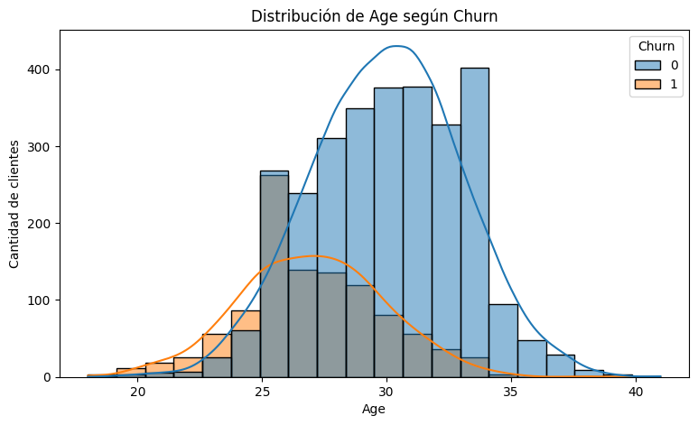

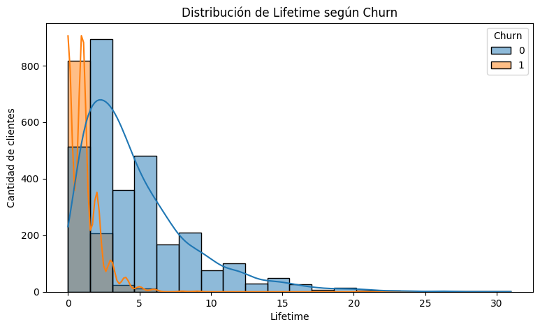

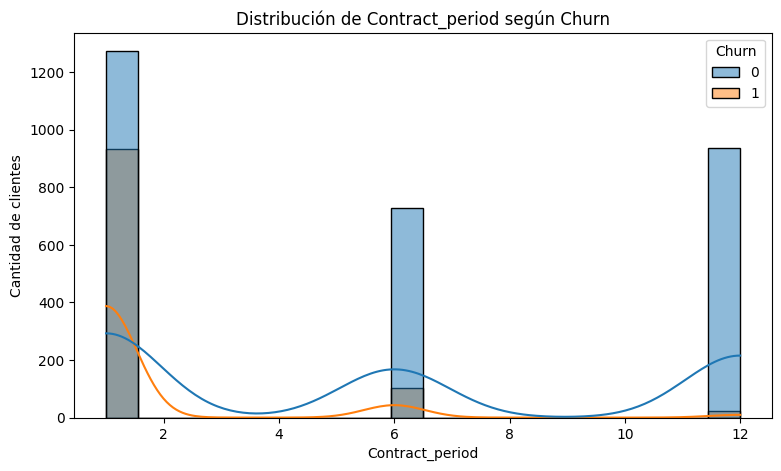

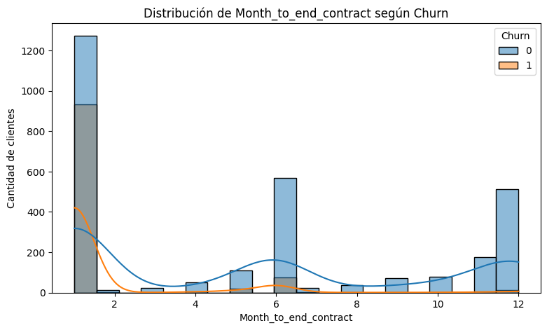

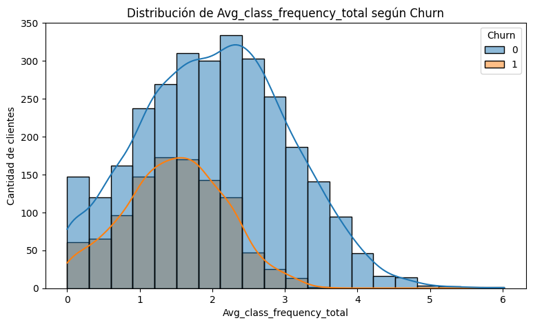

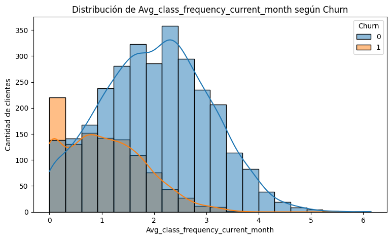

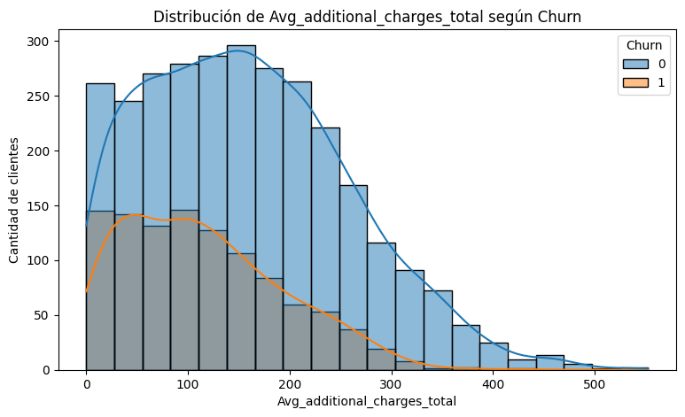

```python
#3.3 Distribución de variables numéricas según Churn
numeric_columns = [
    'Age',
    'Lifetime',
    'Contract_period',
    'Month_to_end_contract',
    'Avg_class_frequency_total',
    'Avg_class_frequency_current_month',
    'Avg_additional_charges_total'
]

for column in numeric_columns:
    plt.figure(figsize=(9, 5))

    sns.histplot(
        data=gym,
        x=column,
        hue='Churn',
        kde=True,
        bins=20
    )

    plt.title(f'Distribución de {column} según Churn')
    plt.xlabel(column)
    plt.ylabel('Cantidad de clientes')
    plt.show()
```

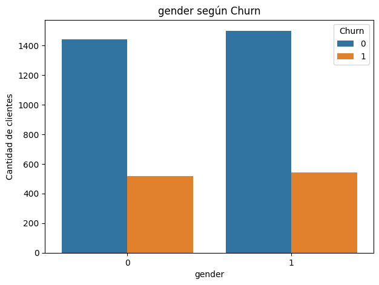

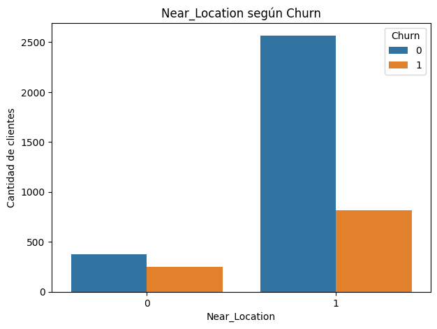

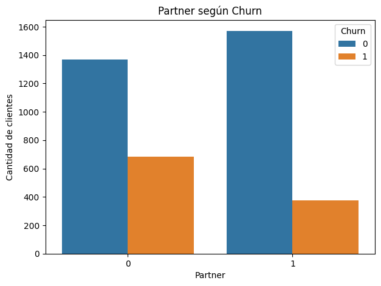

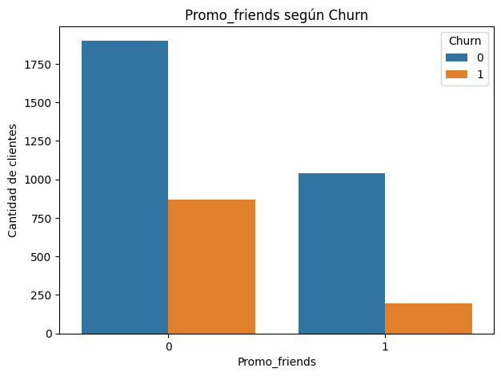

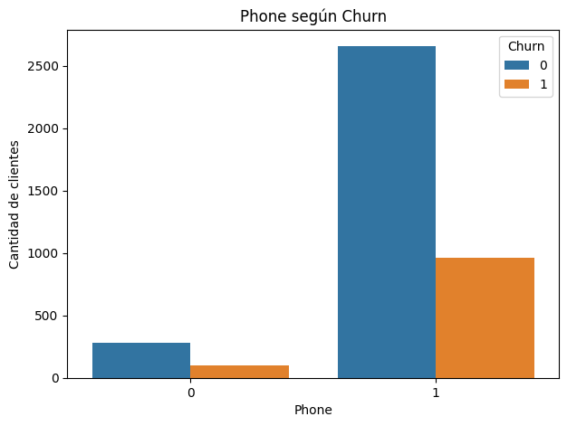

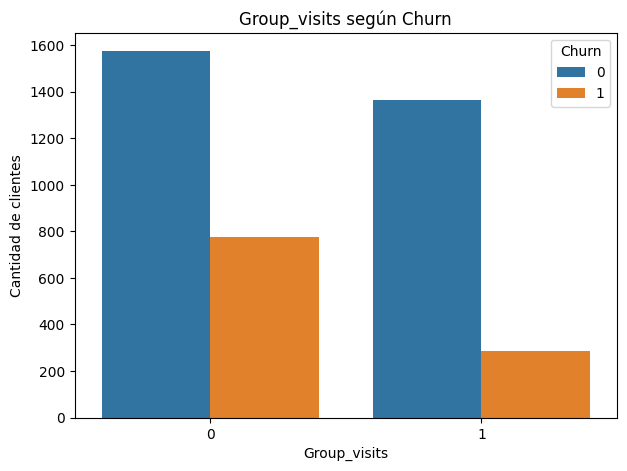

```python
# 3.4 Distribución de variables binarias
binary_columns = [
    'gender',
    'Near_Location',
    'Partner',
    'Promo_friends',
    'Phone',
    'Group_visits'
]

for column in binary_columns:
    plt.figure(figsize=(7, 5))

    sns.countplot(
        data=gym,
        x=column,
        hue='Churn'
    )

    plt.title(f'{column} según Churn')
    plt.xlabel(column)
    plt.ylabel('Cantidad de clientes')
    plt.show()
```

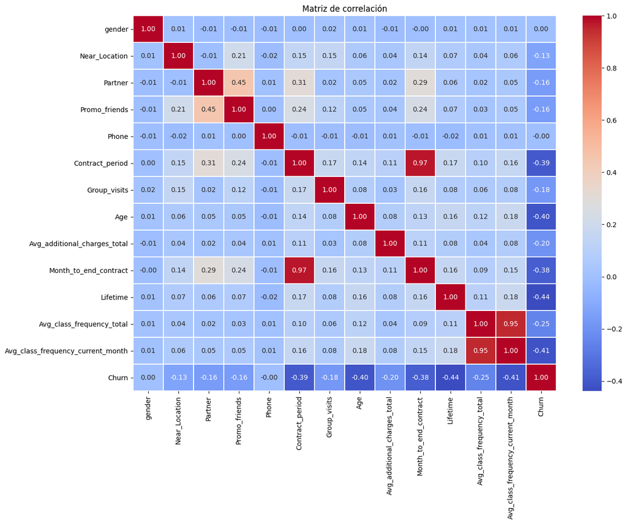

```python
# 3.5 Matriz de correlación
plt.figure(figsize=(14, 10))

sns.heatmap(
    gym.corr(),
    annot=True,
    fmt='.2f',
    cmap='coolwarm',
    linewidths=0.5
)

plt.title('Matriz de correlación')
plt.show()
```

**Comentario del revisor**  
**Éxito** - El análisis exploratorio cumple con los elementos principales solicitados: se comparan los valores medios de las características según `Churn`, se calcula la proporción general de cancelación, se muestran distribuciones para variables numéricas y binarias y se construye la matriz de correlación. Además, la separación entre clientes que permanecieron y quienes cancelaron permite visualizar diferencias relevantes entre ambos grupos.

4. MODELOS DE PREDICCIÓN

```python
# 4.1 Separar características y variable objetivo
X = gym.drop('Churn', axis=1)
y = gym['Churn']
```

```python
# 4.2 División en entrenamiento y validación
X_train, X_valid, y_train, y_valid = train_test_split(
    X,
    y,
    test_size=0.2,
    random_state=42,
    stratify=y
)

print('Tamaño entrenamiento:', X_train.shape)
print('Tamaño validación:', X_valid.shape)
```

```
Tamaño entrenamiento: (3200, 13)
Tamaño validación: (800, 13)
```

**Comentario del revisor**  
**Éxito** - La preparación de los datos para el modelado está correctamente realizada. Se separan las características de la variable objetivo `Churn` y se divide el conjunto en entrenamiento y validación con `train_test_split()`, utilizando `random_state` como solicita la consigna. Las dimensiones obtenidas para ambos conjuntos son coherentes.

5. Regresión logística

```python
# 5.1 Estandarización
scaler = StandardScaler()

X_train_scaled = scaler.fit_transform(X_train)
X_valid_scaled = scaler.transform(X_valid)
```

```python
# 5.2 Entrenamiento
logistic_model = LogisticRegression(
    random_state=42,
    max_iter=1000
)

logistic_model.fit(
    X_train_scaled,
    y_train
)
```

```
LogisticRegression(max_iter=1000, random_state=42)
```

```python
# 5.3 Predicciones
logistic_pred = logistic_model.predict(X_valid_scaled)
```

```python
# 5.4 Métricas
logistic_accuracy = accuracy_score(
    y_valid,
    logistic_pred
)

logistic_precision = precision_score(
    y_valid,
    logistic_pred
)

logistic_recall = recall_score(
    y_valid,
    logistic_pred
)

print('REGRESIÓN LOGÍSTICA')
print('Accuracy:', round(logistic_accuracy, 3))
print('Precision:', round(logistic_precision, 3))
print('Recall:', round(logistic_recall, 3))
```

```
REGRESIÓN LOGÍSTICA
Accuracy: 0.925
Precision: 0.88
Recall: 0.83
```

**Comentario del revisor**  
**Éxito** - La regresión logística está correctamente implementada. Se estandarizan las características utilizando únicamente el conjunto de entrenamiento para ajustar el escalador, se entrena el modelo con `random_state`, se generan las predicciones sobre validación y se calculan correctamente las tres métricas solicitadas en la consigna: *accuracy*, *precision* y *recall*.

6. Random Forest

```python
# 6.1 Entrenamiento
forest_model = RandomForestClassifier(
    n_estimators=100,
    random_state=42
)

forest_model.fit(
    X_train,
    y_train
)
```

```
RandomForestClassifier(random_state=42)
```

```python
# 6.2 Predicciones
forest_pred = forest_model.predict(X_valid)
```

```python
# 6.3 Métricas
forest_accuracy = accuracy_score(
    y_valid,
    forest_pred
)

forest_precision = precision_score(
    y_valid,
    forest_pred
)

forest_recall = recall_score(
    y_valid,
    forest_pred
)

print('RANDOM FOREST')
print('Accuracy:', round(forest_accuracy, 3))
print('Precision:', round(forest_precision, 3))
print('Recall:', round(forest_recall, 3))
```

```
RANDOM FOREST
Accuracy: 0.928
Precision: 0.885
Recall: 0.835
```

**Comentario del revisor**

**Éxito** - El modelo de Random Forest está correctamente entrenado y evaluado. Se utiliza `random_state` como solicita la consigna, las predicciones se realizan sobre el conjunto de validación y se calculan correctamente las métricas de *accuracy*, *precision* y *recall*, lo que permitirá compararlo con la regresión logística.

7. Comparación de modelos

```python
models_comparison = pd.DataFrame({
    'Modelo': [
        'Regresión logística',
        'Random Forest'
    ],
    'Accuracy': [
        logistic_accuracy,
        forest_accuracy
    ],
    'Precision': [
        logistic_precision,
        forest_precision
    ],
    'Recall': [
        logistic_recall,
        forest_recall
    ]
})

models_comparison
```

|  | Modelo | Accuracy | Precision | Recall |
| --- | --- | --- | --- | --- |
| 0 | Regresión logística | 0.9250 | 0.880 | 0.830189 |
| 1 | Random Forest | 0.9275 | 0.885 | 0.834906 |

```python
models_comparison.sort_values(
    by='Accuracy',
    ascending=False
)
```

|  | Modelo | Accuracy | Precision | Recall |
| --- | --- | --- | --- | --- |
| 1 | Random Forest | 0.9275 | 0.885 | 0.834906 |
| 0 | Regresión logística | 0.9250 | 0.880 | 0.830189 |

**Comentario del revisor**  
**Éxito** - La comparación entre los dos modelos está correctamente realizada utilizando las tres métricas solicitadas: *accuracy*, *precision* y *recall*. Los resultados muestran que Random Forest obtiene valores ligeramente superiores en las tres métricas, por lo que queda correctamente identificado como el modelo con mejor desempeño en esta comparación.

8. Importancia de las características

```python
feature_importance = pd.DataFrame({
    'feature': X.columns,
    'importance': forest_model.feature_importances_
})

feature_importance = feature_importance.sort_values(
    by='importance',
    ascending=False
)

feature_importance
```

|  | feature | importance |
| --- | --- | --- |
| 10 | Lifetime | 0.281499 |
| 12 | Avg_class_frequency_current_month | 0.161732 |
| 7 | Age | 0.133650 |
| 11 | Avg_class_frequency_total | 0.129011 |
| 8 | Avg_additional_charges_total | 0.089380 |
| 9 | Month_to_end_contract | 0.069467 |
| 5 | Contract_period | 0.067036 |
| 6 | Group_visits | 0.017554 |
| 0 | gender | 0.011483 |
| 2 | Partner | 0.011263 |
| 1 | Near_Location | 0.010616 |
| 3 | Promo_friends | 0.010262 |
| 4 | Phone | 0.007046 |

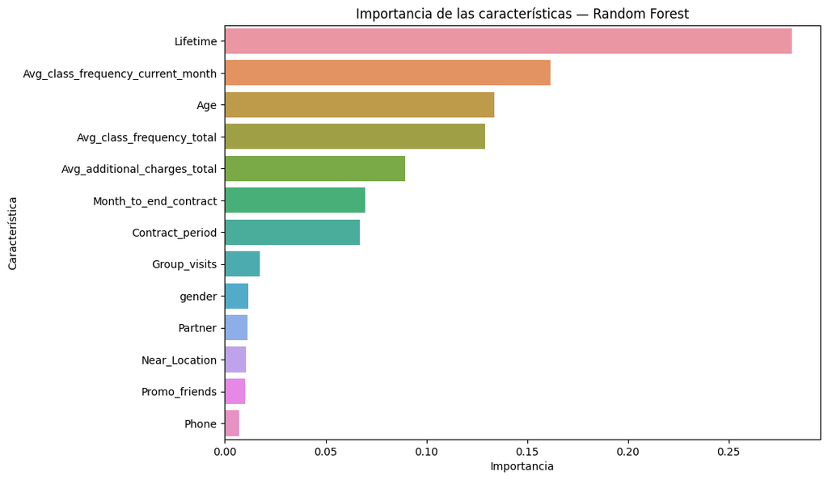

```python
# Grafico
plt.figure(figsize=(10, 7))

sns.barplot(
    data=feature_importance,
    x='importance',
    y='feature'
)

plt.title('Importancia de las características — Random Forest')
plt.xlabel('Importancia')
plt.ylabel('Característica')
plt.show()
```

**Comentario del revisor**  
**Éxito** - El análisis de importancia de características está correctamente planteado y aporta información útil para identificar qué variables tienen mayor peso en las predicciones del modelo. En particular, se observa que `Lifetime`, la frecuencia de visitas del mes actual, la edad y la frecuencia histórica de visitas destacan entre las variables más influyentes, lo que será útil para relacionar el modelo con el problema de cancelación de clientes.

9. CLUSTERING

```python
gym_cluster = gym.drop('Churn', axis=1).copy()

gym_cluster.head()
```

|  | gender | Near_Location | Partner | Promo_friends | Phone | Contract_period | Group_visits | Age | Avg_additional_charges_total | Month_to_end_contract | Lifetime | Avg_class_frequency_total | Avg_class_frequency_current_month |
| --- | --- | --- | --- | --- | --- | --- | --- | --- | --- | --- | --- | --- | --- |
| 0 | 1 | 1 | 1 | 1 | 0 | 6 | 1 | 29 | 14.227470 | 5.0 | 3 | 0.020398 | 0.000000 |
| 1 | 0 | 1 | 0 | 0 | 1 | 12 | 1 | 31 | 113.202938 | 12.0 | 7 | 1.922936 | 1.910244 |
| 2 | 0 | 1 | 1 | 0 | 1 | 1 | 0 | 28 | 129.448479 | 1.0 | 2 | 1.859098 | 1.736502 |
| 3 | 0 | 1 | 1 | 1 | 1 | 12 | 1 | 33 | 62.669863 | 12.0 | 2 | 3.205633 | 3.357215 |
| 4 | 1 | 1 | 1 | 1 | 1 | 1 | 0 | 26 | 198.362265 | 1.0 | 3 | 1.113884 | 1.120078 |

**Comentario del revisor**  
**Éxito** - La preparación de los datos para el clustering está correctamente realizada. Se elimina la variable objetivo `Churn`, tal como solicita la consigna, y se conserva el resto de las características para identificar grupos de clientes a partir de su comportamiento y características.

10. Estandarización para clustering

```python
scaler_cluster = StandardScaler()

gym_scaled = scaler_cluster.fit_transform(
    gym_cluster
)

gym_scaled.shape
```

```
(4000, 13)
```

**Comentario del revisor**  
**Éxito** - La estandarización para el clustering está correctamente realizada con `StandardScaler`. Se transforman las 13 características utilizadas para agrupar a los clientes y se conserva el total de 4000 registros, preparando adecuadamente los datos para los siguientes pasos de análisis jerárquico y K-means.

11. Dendrograma

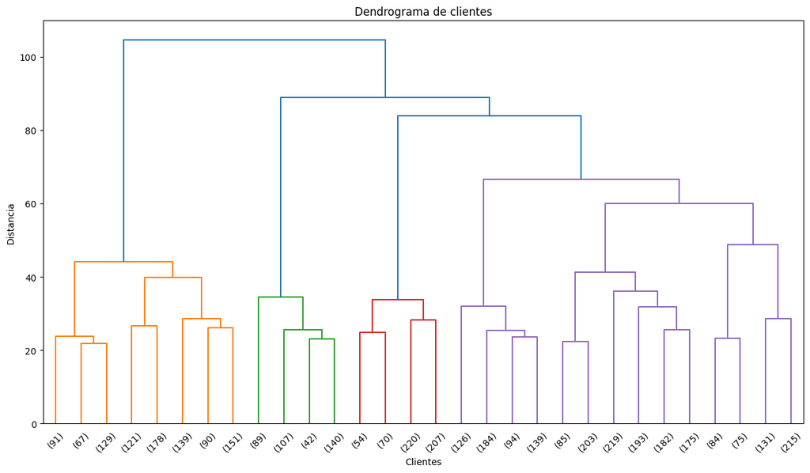

```python
linked = linkage(
    gym_scaled,
    method='ward'
)

plt.figure(figsize=(15, 8))

dendrogram(
    linked,
    truncate_mode='lastp',
    p=30
)

plt.title('Dendrograma de clientes')
plt.xlabel('Clientes')
plt.ylabel('Distancia')
plt.show()
```

**Comentario del revisor**  
**Éxito** - El dendrograma está correctamente construido a partir de las características estandarizadas utilizando `linkage()` con el método `ward`. Esta visualización permite explorar la estructura de agrupamiento de los clientes antes de aplicar K-means, cumpliendo con lo solicitado en esta etapa.

12. K-Means

```python
km = KMeans(
    n_clusters=5,
    random_state=42,
    n_init=10
)

clusters = km.fit_predict(gym_scaled)
```

```python
gym['cluster'] = clusters

gym.head()
```

|  | gender | Near_Location | Partner | Promo_friends | Phone | Contract_period | Group_visits | Age | Avg_additional_charges_total | Month_to_end_contract | Lifetime | Avg_class_frequency_total | Avg_class_frequency_current_month | Churn | cluster |
| --- | --- | --- | --- | --- | --- | --- | --- | --- | --- | --- | --- | --- | --- | --- | --- |
| 0 | 1 | 1 | 1 | 1 | 0 | 6 | 1 | 29 | 14.227470 | 5.0 | 3 | 0.020398 | 0.000000 | 0 | 4 |
| 1 | 0 | 1 | 0 | 0 | 1 | 12 | 1 | 31 | 113.202938 | 12.0 | 7 | 1.922936 | 1.910244 | 0 | 2 |
| 2 | 0 | 1 | 1 | 0 | 1 | 1 | 0 | 28 | 129.448479 | 1.0 | 2 | 1.859098 | 1.736502 | 0 | 3 |
| 3 | 0 | 1 | 1 | 1 | 1 | 12 | 1 | 33 | 62.669863 | 12.0 | 2 | 3.205633 | 3.357215 | 0 | 2 |
| 4 | 1 | 1 | 1 | 1 | 1 | 1 | 0 | 26 | 198.362265 | 1.0 | 3 | 1.113884 | 1.120078 | 0 | 0 |

**Comentario del revisor**  
**Éxito** - La aplicación de K-means está correctamente realizada. Se utiliza el número de clústeres solicitado en la consigna (`n_clusters=5`), se fija `random_state` y el modelo se entrena sobre los datos estandarizados. Además, las etiquetas de clúster se incorporan correctamente al dataset para poder analizar posteriormente las características y la tasa de cancelación de cada grupo.

13. Cantidad de clientes por clúster

```python
cluster_counts = gym['cluster'].value_counts().sort_index()
cluster_counts
```

```
0     633
1     889
2     865
3    1227
4     386
Name: cluster, dtype: int64
```

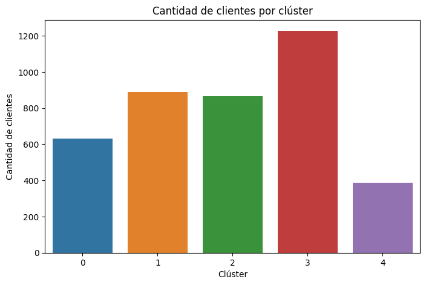

```python
# Grafico
plt.figure(figsize=(8, 5))

sns.countplot(
    data=gym,
    x='cluster'
)

plt.title('Cantidad de clientes por clúster')
plt.xlabel('Clúster')
plt.ylabel('Cantidad de clientes')
plt.show()
```

**Comentario del revisor**  
**Éxito** - La cantidad de clientes por clúster está correctamente calculada y representada gráficamente. Esto permite observar el tamaño relativo de cada uno de los cinco grupos identificados y complementa adecuadamente el análisis de segmentación.

14. Valores medios de las características por clúster

```python
cluster_means_without_churn = (
    gym.drop('Churn', axis=1)
       .groupby('cluster')
       .mean()
)

cluster_means_without_churn
```

| cluster | gender | Near_Location | Partner | Promo_friends | Phone | Contract_period | Group_visits | Age | Avg_additional_charges_total | Month_to_end_contract | Lifetime | Avg_class_frequency_total | Avg_class_frequency_current_month |
| --- | --- | --- | --- | --- | --- | --- | --- | --- | --- | --- | --- | --- | --- |
| 0 | 0.502370 | 0.949447 | 0.829384 | 0.998420 | 1.0 | 3.097946 | 0.448657 | 29.104265 | 141.774331 | 2.887836 | 3.772512 | 1.770536 | 1.669581 |
| 1 | 0.554556 | 0.849269 | 0.263217 | 0.052868 | 1.0 | 2.606299 | 0.436445 | 30.008999 | 159.774265 | 2.419573 | 4.780652 | 2.745505 | 2.733173 |
| 2 | 0.499422 | 0.937572 | 0.737572 | 0.478613 | 1.0 | 11.854335 | 0.546821 | 29.905202 | 163.509804 | 10.812717 | 4.677457 | 2.006405 | 1.998179 |
| 3 | 0.485738 | 0.718011 | 0.299919 | 0.018745 | 1.0 | 1.914425 | 0.276284 | 28.083945 | 129.496414 | 1.821516 | 2.195599 | 1.225192 | 0.967967 |
| 4 | 0.523316 | 0.862694 | 0.471503 | 0.305699 | 0.0 | 4.777202 | 0.427461 | 29.297927 | 144.208179 | 4.466321 | 3.940415 | 1.854211 | 1.723967 |

**Comentario del revisor**  
**Éxito** - Los valores medios de las características por clúster están correctamente calculados. La tabla permite distinguir perfiles diferentes entre los grupos, por ejemplo en variables como la duración del contrato, la frecuencia de visitas, la participación en promociones y la antigüedad de los clientes, cumpliendo con esta parte del análisis de clustering.

15. Distribución de características por clúster

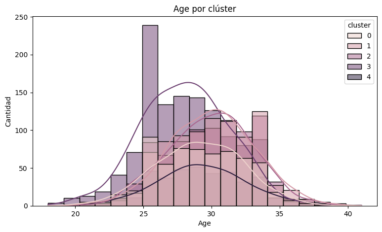

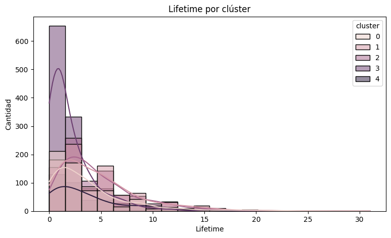

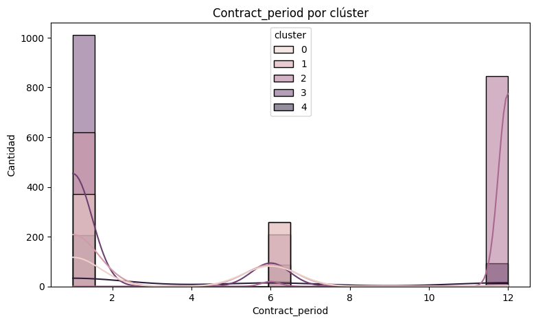

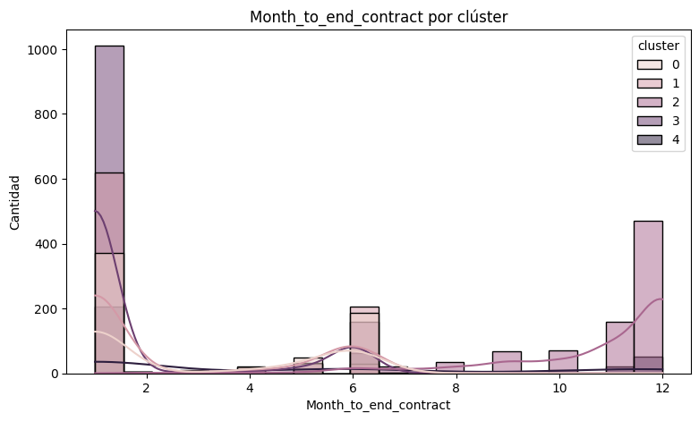

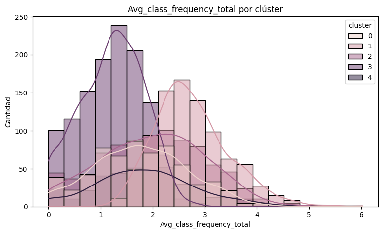

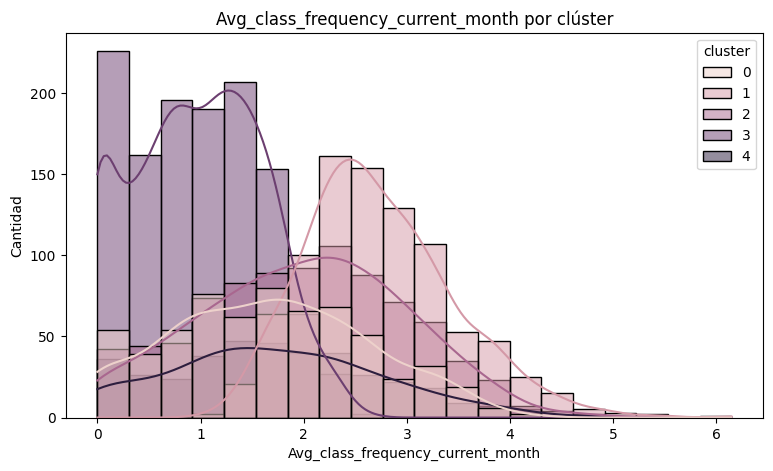

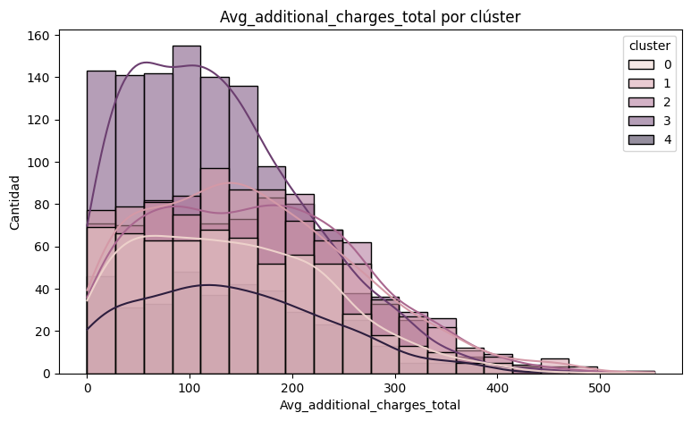

```python
for column in numeric_columns:
    plt.figure(figsize=(9, 5))

    sns.histplot(
        data=gym,
        x=column,
        hue='cluster',
        bins=20,
        kde=True
    )

    plt.title(f'{column} por clúster')
    plt.xlabel(column)
    plt.ylabel('Cantidad')
    plt.show()
```

**Comentario del revisor**  
**Éxito** - Las distribuciones de las características numéricas por clúster están correctamente representadas. Los gráficos permiten comparar visualmente los cinco grupos e identificar diferencias en variables como edad, antigüedad, duración del contrato, frecuencia de visitas y gastos adicionales, cumpliendo con lo solicitado en esta parte del análisis de clustering.

16. Variables binarias por clúster

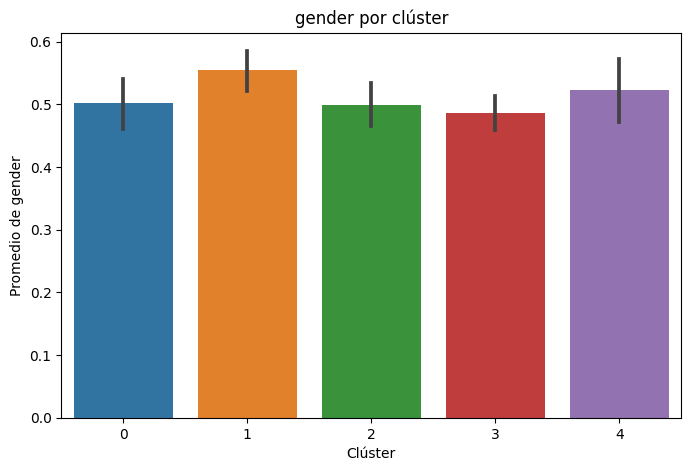

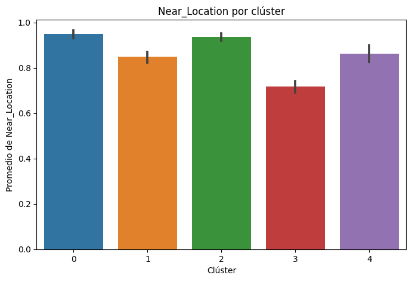

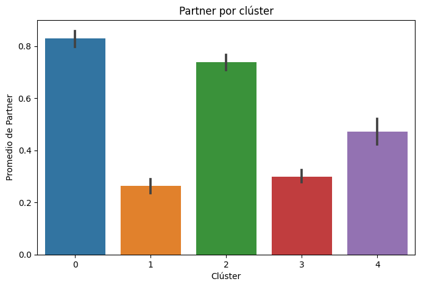

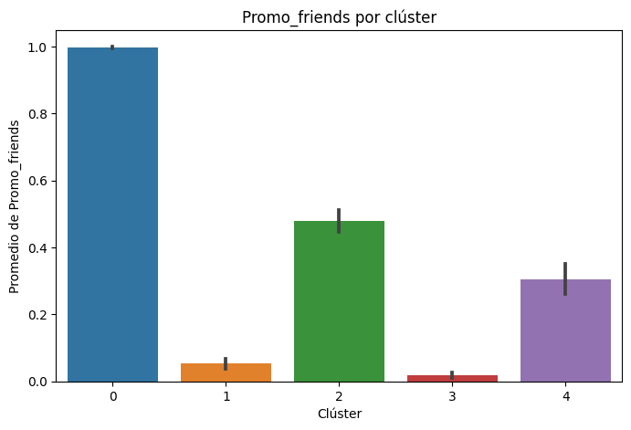

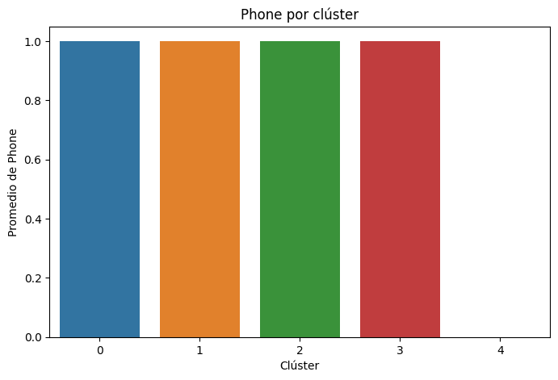

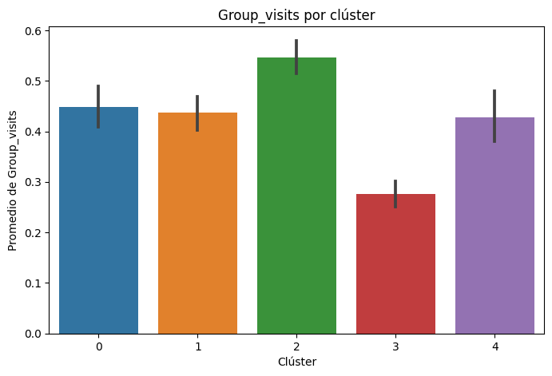

```python
for column in binary_columns:
    plt.figure(figsize=(8, 5))

    sns.barplot(
        data=gym,
        x='cluster',
        y=column
    )

    plt.title(f'{column} por clúster')
    plt.xlabel('Clúster')
    plt.ylabel(f'Promedio de {column}')
    plt.show()
```

**Comentario del revisor**  
**Éxito** - Las variables binarias se comparan correctamente entre los clústeres mediante sus valores medios. Dado que estas variables están codificadas como 0 y 1, los gráficos permiten interpretar fácilmente la proporción aproximada de clientes de cada clúster que presenta cada característica y complementan adecuadamente la descripción de los perfiles.

17. Tasa de cancelación por clúster

```python
churn_by_cluster = gym.groupby('cluster')['Churn'].mean()
churn_by_cluster
```

```
cluster
0    0.246445
1    0.089989
2    0.021965
3    0.572942
4    0.266839
Name: Churn, dtype: float64
```

```python
# Porcentaje
churn_by_cluster_percent = (
    churn_by_cluster * 100
).round(2)

churn_by_cluster_percent
```

```
cluster
0    24.64
1     9.00
2     2.20
3    57.29
4    26.68
Name: Churn, dtype: float64
```

**Comentario del revisor**  
**Éxito** - La tasa de cancelación por clúster está correctamente calculada y permite distinguir claramente los grupos con comportamientos diferentes. El clúster 3 presenta la mayor tasa de cancelación (57.29%), mientras que el clúster 2 muestra la menor (2.20%), lo que permite identificar adecuadamente los grupos más propensos a abandonar y los más leales.

18. Gráfico de cancelación por clúster

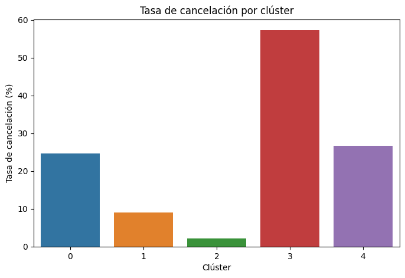

```python
plt.figure(figsize=(8, 5))

sns.barplot(
    x=churn_by_cluster_percent.index,
    y=churn_by_cluster_percent.values
)

plt.title('Tasa de cancelación por clúster')
plt.xlabel('Clúster')
plt.ylabel('Tasa de cancelación (%)')
plt.show()
```

**Comentario del revisor**  
**Éxito** - La tasa de cancelación por clúster está correctamente representada mediante un gráfico de barras, facilitando la comparación visual entre los cinco grupos y permitiendo identificar rápidamente cuáles presentan mayor y menor riesgo de abandono.

19. Tabla final de clústeres

```python
cluster_summary = gym.groupby('cluster').agg(
    clientes=('Churn', 'count'),
    churn_rate=('Churn', 'mean'),
    edad=('Age', 'mean'),
    antiguedad=('Lifetime', 'mean'),
    contrato=('Contract_period', 'mean'),
    meses_fin_contrato=('Month_to_end_contract', 'mean'),
    visitas_totales=('Avg_class_frequency_total', 'mean'),
    visitas_mes_actual=('Avg_class_frequency_current_month', 'mean'),
    gastos_extra=('Avg_additional_charges_total', 'mean')
)

cluster_summary['churn_rate'] = (
    cluster_summary['churn_rate'] * 100
).round(2)

cluster_summary.round(2)
```

| cluster | clientes | churn_rate | edad | antiguedad | contrato | meses_fin_contrato | visitas_totales | visitas_mes_actual | gastos_extra |
| --- | --- | --- | --- | --- | --- | --- | --- | --- | --- |
| 0 | 633 | 24.64 | 29.10 | 3.77 | 3.10 | 2.89 | 1.77 | 1.67 | 141.77 |
| 1 | 889 | 9.00 | 30.01 | 4.78 | 2.61 | 2.42 | 2.75 | 2.73 | 159.77 |
| 2 | 865 | 2.20 | 29.91 | 4.68 | 11.85 | 10.81 | 2.01 | 2.00 | 163.51 |
| 3 | 1227 | 57.29 | 28.08 | 2.20 | 1.91 | 1.82 | 1.23 | 0.97 | 129.50 |
| 4 | 386 | 26.68 | 29.30 | 3.94 | 4.78 | 4.47 | 1.85 | 1.72 | 144.21 |

**Comentario del revisor**  
**Éxito** - La tabla resumen integra correctamente el tamaño de cada clúster, su tasa de cancelación y las principales características medias de los clientes. Esto facilita la comparación entre perfiles y permite identificar con claridad al clúster 3 como el grupo con mayor riesgo de cancelación y al clúster 2 como el más leal.

20. Ordenar los clústeres según riesgo

```python
cluster_summary.sort_values(
    by='churn_rate',
    ascending=False
).round(2)
```

| cluster | clientes | churn_rate | edad | antiguedad | contrato | meses_fin_contrato | visitas_totales | visitas_mes_actual | gastos_extra |
| --- | --- | --- | --- | --- | --- | --- | --- | --- | --- |
| 3 | 1227 | 57.29 | 28.08 | 2.20 | 1.91 | 1.82 | 1.23 | 0.97 | 129.50 |
| 4 | 386 | 26.68 | 29.30 | 3.94 | 4.78 | 4.47 | 1.85 | 1.72 | 144.21 |
| 0 | 633 | 24.64 | 29.10 | 3.77 | 3.10 | 2.89 | 1.77 | 1.67 | 141.77 |
| 1 | 889 | 9.00 | 30.01 | 4.78 | 2.61 | 2.42 | 2.75 | 2.73 | 159.77 |
| 2 | 865 | 2.20 | 29.91 | 4.68 | 11.85 | 10.81 | 2.01 | 2.00 | 163.51 |

**Comentario del revisor**  
**Éxito** - La clasificación de los clústeres según su tasa de cancelación está correctamente realizada. El orden obtenido permite identificar con claridad los grupos de mayor riesgo, encabezados por el clúster 3, y los grupos más leales, especialmente el clúster 2, facilitando la posterior formulación de estrategias de retención.

21. Resumen final de modelos

```python
print('========== COMPARACIÓN DE MODELOS ==========')

print(
    models_comparison.round(3)
)
```

```
========== COMPARACIÓN DE MODELOS ==========
                Modelo  Accuracy  Precision  Recall
0  Regresión logística     0.925      0.880   0.830
1        Random Forest     0.928      0.885   0.835
```

**Comentario del revisor**  
**Éxito** - El resumen final presenta de forma clara y correcta las métricas de ambos modelos. La comparación confirma que Random Forest obtiene resultados ligeramente superiores a la regresión logística en *accuracy*, *precision* y *recall*, manteniendo coherencia con el análisis realizado anteriormente.

22. Resumen de importancia de características

```python
print('========== IMPORTANCIA DE CARACTERÍSTICAS ==========')

print(
    feature_importance.round(4)
)
```

```
========== IMPORTANCIA DE CARACTERÍSTICAS ==========
                              feature  importance
10                           Lifetime      0.2815
12  Avg_class_frequency_current_month      0.1617
7                                 Age      0.1337
11          Avg_class_frequency_total      0.1290
8        Avg_additional_charges_total      0.0894
9               Month_to_end_contract      0.0695
5                     Contract_period      0.0670
6                        Group_visits      0.0176
0                              gender      0.0115
2                             Partner      0.0113
1                       Near_Location      0.0106
3                       Promo_friends      0.0103
4                               Phone      0.0070
```

**Comentario del revisor**  
**Éxito** - El resumen presenta correctamente la importancia de las características obtenida con Random Forest y mantiene coherencia con los resultados anteriores. Se identifican claramente `Lifetime`, la frecuencia de visitas del mes actual, la edad y la frecuencia histórica de visitas como las variables con mayor importancia dentro del modelo.

23. Resumen de clústeres

```python
print('========== RESUMEN DE CLÚSTERES ==========')

print(
    cluster_summary.round(2)
)
```

```
========== RESUMEN DE CLÚSTERES ==========
         clientes  churn_rate   edad  antiguedad  contrato  \
cluster
0             633       24.64  29.10        3.77      3.10
1             889        9.00  30.01        4.78      2.61
2             865        2.20  29.91        4.68     11.85
3            1227       57.29  28.08        2.20      1.91
4             386       26.68  29.30        3.94      4.78

         meses_fin_contrato  visitas_totales  visitas_mes_actual  gastos_extra
cluster
0                      2.89             1.77                1.67        141.77
1                      2.42             2.75                2.73        159.77
2                     10.81             2.01                2.00        163.51
3                      1.82             1.23                0.97        129.50
4                      4.47             1.85                1.72        144.21
```

**Comentario del revisor**  
**Éxito** - El resumen de clústeres está correctamente presentado y reúne de forma clara la información principal de cada grupo: tamaño, tasa de cancelación, edad, antigüedad, duración del contrato, frecuencia de visitas y gastos adicionales. Esto facilita comparar los perfiles y distinguir con claridad los clústeres de mayor y menor riesgo de cancelación.

24. CONCLUSIONES Y RECOMENDACIONES DEL PROYECTO

Conclusión El análisis realizado sobre los clientes de Model Fitness permitió identificar los principales factores relacionados con la cancelación y establecer grupos de clientes con diferentes niveles de riesgo.

En cuanto a los modelos de predicción, tanto la regresión logística como Random Forest mostraron un buen desempeño. Random Forest presentó un rendimiento ligeramente superior, por lo que puede utilizarse como herramienta para identificar clientes con mayor probabilidad de cancelar.

Entre los factores más importantes para predecir la cancelación destacan principalmente la antigüedad del cliente (Lifetime), la frecuencia de visitas durante el mes actual, la edad, la frecuencia promedio de visitas y el gasto en servicios adicionales. Los clientes que presentan una menor frecuencia de visitas tienen un mayor riesgo de abandonar el gimnasio.

En conclusión, Model Fitness puede utilizar los modelos predictivos y la segmentación de clientes para identificar anticipadamente a las personas con mayor riesgo de cancelación. Concentrar los esfuerzos de retención en los clústeres con mayor riesgo y aprender de las características de los grupos más leales permitirá desarrollar una estrategia de interacción más eficiente y reducir la rotación de clientes.

- Corregir la conclusión y las recomendaciones para identificar a los clústeres 3 y 4 como los grupos con mayor tasa de cancelación.
- Mantener al clúster 0 como un grupo de riesgo relevante, pero por detrás del clúster 4.

El resto de las conclusiones y recomendaciones mantiene una buena relación con los resultados obtenidos.